# Analyze Covid-19 Situation In Malaysia

#### Starting in October 2020, the covid-19 case started to increase rapidly mainly is caused by new covid-19 species and it has been brought into Malaysia. Example of Corona Mutated species are Alpha, Beta, Delta, and omicron. The situation starting to turn into chaos in Malaysia because they faced insufficient test kits, vaccines, lack of equipment in the hospital to take care of the patients, the citizen is less care about the discipline or lack of self-control, lack of proper prevention plans, etc. Hence, these are the factors that caused the cases to grow rapidly in Malaysia.

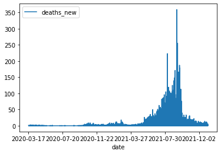

```python
# Line chart for deaths cases.
fCTotal.plot.line(x='date', y='deaths_new')
```

```python
# Calculate the infection and recovery rate in Malaysia
# then visualize it

newCase = fCTotal['cases_new']/100
recoveredCase = fCTotal['cases_recovered']/100
```

[output not shown]

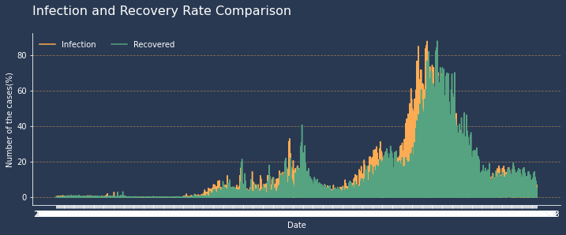

```python
# Check the recovered and new cases

# figure
fig, ax = plt.subplots(1, figsize=(12,4), facecolor='#293952')
ax.set_facecolor('#293952')

# Plot the lines
plt.plot(fCTotal.date, newCase, color='#FDAC53')
plt.plot(fCTotal.date, recoveredCase, color='#55A380')

# Set the name/title
plt.title('Infection and Recovery Rate Comparison\n', loc='left', color='w', fontsize=16)
plt.xlabel('Date', color='w')
plt.ylabel('Number of the cases(%)', color='w')

ax.tick_params(axis='both', colors='white')
ax.spines['right'].set_visible(False)
ax.spines['top'].set_visible(False)
ax.spines['left'].set_color('w')
ax.spines['bottom'].set_color('w')

# Set the grid
ax.set_axisbelow(True)
ax.yaxis.grid(color='#FDAC53', linestyle='dashed', alpha=0.5)

# Set the legend
legend = plt.legend(['Infection', 'Recovered'], frameon=False, ncol=2)
plt.setp(legend.get_texts(), color='w')
```

#### Although Malaysia has a high infection rate the victims are still able to recover themself quickly, which proofed that the recovery rate is high as well. This should be seen as a positive development or a piece of good news, not only for Malaysia but for the whole world. After changing the Cabinets, the current government started to control back the situation which both rates drop drastically at the end of 2021, thank our new health minister's contribution.

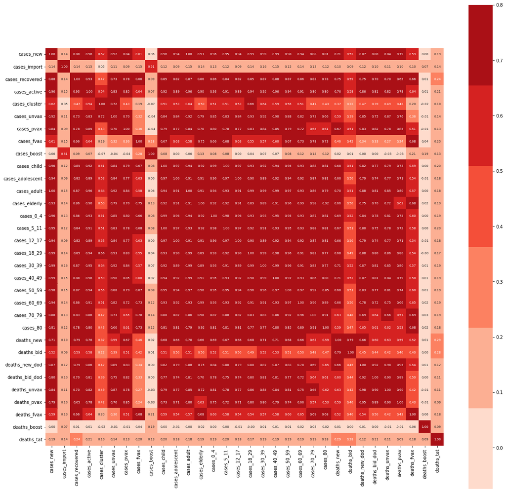

```python
# Correlation plot
cp = covidCase.corr()
plt.figure(figsize=(20,20))
sns.heatmap(cp, vmax=.8, square=True, annot=True, fmt='.2f',
            annot_kws={'size': 7}, cmap=sns.color_palette('Reds'))
```

#### As a summarization, this is a correlation plot used to check whether these factors affected that particular factor or not. If the correlation value is high which indicated both factors/variables have a strong relationship else both of them do not have or weak relationship if the value is closer to 0.